# Locus Leads against plink2 clumping across EUR Analyses (#403)

Published

November 6, 2026

## The question

Does genetic-distance pruning work for EUR? Is there a D and a W at which the number of Locus Leads in an Analysis (`n_loci_*`) tracks plink2’s r² 0.01 index variants in rank and does not depend on variant density, and does a genetic-distance condition do better than a plain base-pair window of the same W? The per-lead agreement with plink2 clumping is reported second, as diagnostics. Only Observed Associations at the 5×10⁻⁸ tier are used, on the rows both methods can see: on the panel, with finite cM. Genetic distances come from the five-population mean pyrho map. Its two single-population spikes are counted below, not removed.

## The Analyses

40 Analyses were drawn with seed 403 from a pool of 7,372 EUR (Assigned Ancestry) Analyses in the genome-wide Stores. 16 have a largest |z| of at least 100 and 28 of at least 38.5, where a float64 p is 0. The draw is in `eur_sweep_selection.json`, written before any clumping ran.

Analyses by observed 5×10⁻⁸ rows (down) and largest |z| (across): in the pool, and drawn.

| rows | <38.5 | 38.5-100 | >=100 |
| --- | --- | --- | --- |
| <1k | 3,448 / 3 | 28 / 3 | 3 / 3 |
| 1k-10k | 1,045 / 3 | 107 / 3 | 21 / 6 |
| 10k-100k | 368 / 3 | 216 / 3 | 29 / 4 |
| >=100k | 11 / 3 | 78 / 3 | 17 / 3 |

**Stores left out of the pool**

[output not shown]

1,999 pool Analyses have no Observed Association at 5×10⁻⁸ and cannot be drawn; each is listed by Store and Analysis in `eur_sweep_selection.json` (`analyses_without_observed_rows`). **Left out for more than 1,000,000 observed rows**

| Store | Analysis | observed rows | largest \|z\| |
| --- | --- | --- | --- |
| OGS-00011 | GCST002047 | 2,314,363 | 111.2 |
| OGS-00011 | GCST004461 | 5,205,455 | 359.5 |

**Drawn, but under 70.0% of rows in the shared set, so not swept**

| Store | Analysis | tier rows | shared | rows absent from the panel |
| --- | --- | --- | --- | --- |
| OGS-00011 | GCST90704633 | 89 | 67.4% | 29 |
| OGS-00012 | GCST90475609 | 775 | 61.7% | 296 |
| OGS-00012 | GCST90477870 | 377 | 0.0% | 375 |

The sweep ran on 37 Analyses: 1,964,596 Observed Associations at the tier, 1,806,262 (91.9%) of them in the shared set both methods rank. Their tiers also hold 454,077 imputed rows, which are not used.

## Count criteria: is `n_loci_*` the right count?

r² 0.01 clumping splits strong peaks into LD shadows, so the per-lead rates below (spurious splits and lost signals) are diagnostics. The owner’s decision is that `n_loci_*`, a per-Analysis count, is judged by **counts**. These criteria were fixed before the counts were computed, and are written into `eur_sweep.json` with this wording.

- **C1, rank. Spearman rho(Locus Leads, r2 0.01 index variants) over the swept Analyses is >= 0.95.**
- **C2, density. For each swept Analysis, restrict the shared set to HapMap3 variants and recompute the leads at every (D, W) and bp-only; no re-clumping. Density ratio = leads(HM3) / leads(full). C2 holds when the median ratio over Analyses is in [0.8, 1.25] and its median |log2| is at most half that of the same ratio for raw row counts (rows(HM3) / rows(full)).**
- **C3, cM against bp-only, at the same W. cM adds value when its best D improves on bp-only by at least 0.01 in rho (C1) or by at least 0.1 in median |log2 density ratio| (C2), without being worse on the other by more than those margins.**
- Reading of C3: at a W, C3 holds when some D improves on that W’s bp-only by at least one margin and is worse on neither by more than its margin; the D that do are listed.
- The point named: the (D, W), bp-only included, that meets C1 and C2 and has the smallest pooled share of leads lost to density, sum over Analyses of max(0, leads(full) - leads(HM3)) / sum of leads(full); the best cM point is named the same way.
- Index variants: plink2 at r2 0.01, on the same shared set as the leads. HapMap3: the canonical ALIDs of /data/opengwasdb/reference/hapmap3-hg38/hm3.grch38.alid.txt (1,206,903 variants, sha256 `4a7c82aa625a`).

### Result

Over 37 swept Analyses, rows in the shared set: 1,806,262, of which 312,521 are HapMap3 variants. The raw row count keeps a median 0.176 of its rows on HapMap3 (median |log2| 2.508), so C2 asks the leads’ median |log2| to be at most 1.254.

- **C1** (ρ ≥ 0.95): met at 24 of 24 points (ρ from 0.982 to 0.997): D 0.1 cM / W 0.25 Mb, D 0.25 cM / W 0.25 Mb, D 0.5 cM / W 0.25 Mb, D 1 cM / W 0.25 Mb, D 2.5 cM / W 0.25 Mb, bp only / W 0.25 Mb, D 0.1 cM / W 1 Mb, D 0.25 cM / W 1 Mb, D 0.5 cM / W 1 Mb, D 1 cM / W 1 Mb, D 2.5 cM / W 1 Mb, bp only / W 1 Mb, D 0.1 cM / W 2.5 Mb, D 0.25 cM / W 2.5 Mb, D 0.5 cM / W 2.5 Mb, D 1 cM / W 2.5 Mb, D 2.5 cM / W 2.5 Mb, bp only / W 2.5 Mb, D 0.1 cM / W 10 Mb, D 0.25 cM / W 10 Mb, D 0.5 cM / W 10 Mb, D 1 cM / W 10 Mb, D 2.5 cM / W 10 Mb, bp only / W 10 Mb.
- **C2**: met at 20 of 24 points: D 0.25 cM / W 0.25 Mb, D 0.5 cM / W 0.25 Mb, D 1 cM / W 0.25 Mb, D 2.5 cM / W 0.25 Mb, bp only / W 0.25 Mb, D 0.25 cM / W 1 Mb, D 0.5 cM / W 1 Mb, D 1 cM / W 1 Mb, D 2.5 cM / W 1 Mb, bp only / W 1 Mb, D 0.25 cM / W 2.5 Mb, D 0.5 cM / W 2.5 Mb, D 1 cM / W 2.5 Mb, D 2.5 cM / W 2.5 Mb, bp only / W 2.5 Mb, D 0.25 cM / W 10 Mb, D 0.5 cM / W 10 Mb, D 1 cM / W 10 Mb, D 2.5 cM / W 10 Mb, bp only / W 10 Mb.
- **Both C1 and C2**: D 0.25 cM / W 0.25 Mb, D 0.5 cM / W 0.25 Mb, D 1 cM / W 0.25 Mb, D 2.5 cM / W 0.25 Mb, bp only / W 0.25 Mb, D 0.25 cM / W 1 Mb, D 0.5 cM / W 1 Mb, D 1 cM / W 1 Mb, D 2.5 cM / W 1 Mb, bp only / W 1 Mb, D 0.25 cM / W 2.5 Mb, D 0.5 cM / W 2.5 Mb, D 1 cM / W 2.5 Mb, D 2.5 cM / W 2.5 Mb, bp only / W 2.5 Mb, D 0.25 cM / W 10 Mb, D 0.5 cM / W 10 Mb, D 1 cM / W 10 Mb, D 2.5 cM / W 10 Mb, bp only / W 10 Mb.

**Named: bp only / W 10 Mb**, losing 4.8% of its leads to density. The best cM point: D 2.5 cM / W 10 Mb, losing 9.3% of its leads to density. **C3** (cM adds value over bp-only at the same W) holds at no W.

### C1 and C2 at every (D, W)

ρ is Spearman’s rank correlation between the Locus Leads and the r² 0.01 index variants across the Analyses. The ratio is leads on HapMap3 rows over leads in the whole shared set, per Analysis; its median and the median of its |log2| are over Analyses. “Lost to density” is the pooled share of leads that vanish when only HapMap3 rows are present.

| W | D | ρ | C1 | median ratio | median \|log2\| | C2 | Analyses with no HM3 lead | leads (full) | leads (HM3) | lost to density |
| --- | --- | --- | --- | --- | --- | --- | --- | --- | --- | --- |
| 0.25 Mb | bp only | 0.996 | yes | 0.818 | 0.290 | yes | 0 | 21,463 | 17,275 | 19.5% |
| 0.25 Mb | 0.1 cM | 0.997 | yes | 0.771 | 0.376 | no | 0 | 26,094 | 19,925 | 23.6% |
| 0.25 Mb | 0.25 cM | 0.996 | yes | 0.805 | 0.313 | yes | 0 | 22,405 | 17,807 | 20.5% |
| 0.25 Mb | 0.5 cM | 0.996 | yes | 0.815 | 0.294 | yes | 0 | 21,614 | 17,360 | 19.7% |
| 0.25 Mb | 1 cM | 0.996 | yes | 0.818 | 0.290 | yes | 0 | 21,492 | 17,285 | 19.6% |
| 0.25 Mb | 2.5 cM | 0.996 | yes | 0.818 | 0.290 | yes | 0 | 21,469 | 17,276 | 19.5% |
| 1 Mb | bp only | 0.993 | yes | 0.864 | 0.212 | yes | 0 | 11,861 | 10,259 | 13.5% |
| 1 Mb | 0.1 cM | 0.997 | yes | 0.777 | 0.364 | no | 0 | 23,035 | 17,656 | 23.4% |
| 1 Mb | 0.25 cM | 0.994 | yes | 0.818 | 0.290 | yes | 0 | 16,704 | 13,685 | 18.1% |
| 1 Mb | 0.5 cM | 0.994 | yes | 0.854 | 0.227 | yes | 0 | 13,951 | 11,819 | 15.3% |
| 1 Mb | 1 cM | 0.993 | yes | 0.865 | 0.210 | yes | 0 | 12,414 | 10,673 | 14.0% |
| 1 Mb | 2.5 cM | 0.993 | yes | 0.863 | 0.212 | yes | 0 | 11,890 | 10,272 | 13.6% |
| 2.5 Mb | bp only | 0.986 | yes | 0.902 | 0.149 | yes | 0 | 8,057 | 7,279 | 9.7% |
| 2.5 Mb | 0.1 cM | 0.997 | yes | 0.778 | 0.363 | no | 0 | 23,009 | 17,634 | 23.4% |
| 2.5 Mb | 0.25 cM | 0.994 | yes | 0.818 | 0.290 | yes | 0 | 16,491 | 13,529 | 18.0% |
| 2.5 Mb | 0.5 cM | 0.992 | yes | 0.861 | 0.216 | yes | 0 | 13,302 | 11,340 | 14.7% |
| 2.5 Mb | 1 cM | 0.989 | yes | 0.887 | 0.173 | yes | 0 | 10,697 | 9,349 | 12.6% |
| 2.5 Mb | 2.5 cM | 0.987 | yes | 0.900 | 0.152 | yes | 0 | 8,500 | 7,608 | 10.5% |
| 10 Mb | bp only | 0.982 | yes | 0.946 | 0.079 | yes | 0 | 3,712 | 3,532 | 4.8% |
| 10 Mb | 0.1 cM | 0.997 | yes | 0.778 | 0.363 | no | 0 | 23,009 | 17,634 | 23.4% |
| 10 Mb | 0.25 cM | 0.994 | yes | 0.818 | 0.290 | yes | 0 | 16,491 | 13,527 | 18.0% |
| 10 Mb | 0.5 cM | 0.992 | yes | 0.861 | 0.216 | yes | 0 | 13,279 | 11,321 | 14.7% |
| 10 Mb | 1 cM | 0.989 | yes | 0.887 | 0.172 | yes | 0 | 10,561 | 9,247 | 12.4% |
| 10 Mb | 2.5 cM | 0.986 | yes | 0.900 | 0.152 | yes | 0 | 7,291 | 6,616 | 9.3% |

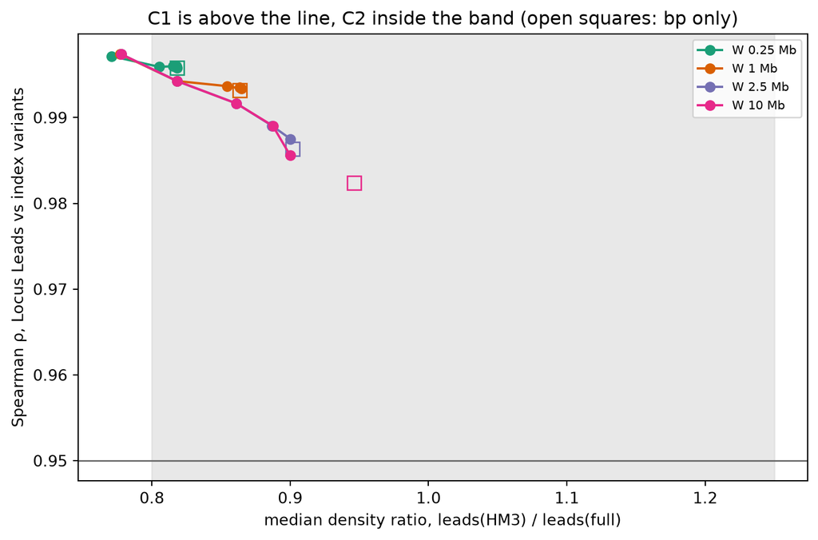

### Leads per index variant

Locus Leads divided by plink2’s r² 0.01 index variants, pooled over the Analyses in a band, by the Analysis’s largest |z| and by its row-count stratum. Below 1 the rule finds fewer loci than clumping; above 1, more.

**By largest |z|** (Analyses per band: <38.5: 11, 38.5-100: 11, >=100: 15)

| W | D | <38.5 | 38.5-100 | >=100 |
| --- | --- | --- | --- | --- |
| 0.25 Mb | 0.1 cM | 1.28 | 1.22 | 1.17 |
| 0.25 Mb | 0.25 cM | 1.14 | 1.03 | 0.99 |
| 0.25 Mb | 0.5 cM | 1.11 | 0.99 | 0.95 |
| 0.25 Mb | 1 cM | 1.10 | 0.98 | 0.95 |
| 0.25 Mb | 2.5 cM | 1.10 | 0.98 | 0.95 |
| 0.25 Mb | bp only | 1.10 | 0.98 | 0.95 |
| 1 Mb | 0.1 cM | 1.11 | 1.08 | 1.04 |
| 1 Mb | 0.25 cM | 0.85 | 0.76 | 0.74 |
| 1 Mb | 0.5 cM | 0.72 | 0.62 | 0.63 |
| 1 Mb | 1 cM | 0.65 | 0.54 | 0.56 |
| 1 Mb | 2.5 cM | 0.63 | 0.50 | 0.54 |
| 1 Mb | bp only | 0.63 | 0.50 | 0.54 |
| 2.5 Mb | 0.1 cM | 1.11 | 1.08 | 1.04 |
| 2.5 Mb | 0.25 cM | 0.84 | 0.75 | 0.73 |
| 2.5 Mb | 0.5 cM | 0.69 | 0.58 | 0.60 |
| 2.5 Mb | 1 cM | 0.57 | 0.45 | 0.49 |
| 2.5 Mb | 2.5 cM | 0.45 | 0.35 | 0.40 |
| 2.5 Mb | bp only | 0.43 | 0.33 | 0.37 |
| 10 Mb | 0.1 cM | 1.11 | 1.08 | 1.04 |
| 10 Mb | 0.25 cM | 0.84 | 0.75 | 0.73 |
| 10 Mb | 0.5 cM | 0.69 | 0.58 | 0.60 |
| 10 Mb | 1 cM | 0.56 | 0.45 | 0.48 |
| 10 Mb | 2.5 cM | 0.39 | 0.29 | 0.34 |
| 10 Mb | bp only | 0.19 | 0.15 | 0.18 |

**By observed 5×10⁻⁸ rows** (Analyses per band: <1k: 6, 1k-10k: 12, 10k-100k: 10, >=100k: 9)

| W | D | <1k | 1k-10k | 10k-100k | >=100k |
| --- | --- | --- | --- | --- | --- |
| 0.25 Mb | 0.1 cM | 0.87 | 1.21 | 1.21 | 1.22 |
| 0.25 Mb | 0.25 cM | 0.70 | 1.08 | 1.06 | 1.03 |
| 0.25 Mb | 0.5 cM | 0.66 | 1.05 | 1.03 | 0.99 |
| 0.25 Mb | 1 cM | 0.66 | 1.04 | 1.02 | 0.99 |
| 0.25 Mb | 2.5 cM | 0.66 | 1.04 | 1.02 | 0.99 |
| 0.25 Mb | bp only | 0.66 | 1.04 | 1.02 | 0.99 |
| 1 Mb | 0.1 cM | 0.82 | 1.07 | 1.06 | 1.08 |
| 1 Mb | 0.25 cM | 0.61 | 0.84 | 0.81 | 0.76 |
| 1 Mb | 0.5 cM | 0.52 | 0.75 | 0.71 | 0.61 |
| 1 Mb | 1 cM | 0.51 | 0.71 | 0.67 | 0.53 |
| 1 Mb | 2.5 cM | 0.51 | 0.69 | 0.65 | 0.50 |
| 1 Mb | bp only | 0.51 | 0.69 | 0.65 | 0.50 |
| 2.5 Mb | 0.1 cM | 0.82 | 1.06 | 1.06 | 1.07 |
| 2.5 Mb | 0.25 cM | 0.61 | 0.82 | 0.81 | 0.75 |
| 2.5 Mb | 0.5 cM | 0.52 | 0.73 | 0.69 | 0.58 |
| 2.5 Mb | 1 cM | 0.49 | 0.64 | 0.60 | 0.44 |
| 2.5 Mb | 2.5 cM | 0.47 | 0.56 | 0.52 | 0.33 |
| 2.5 Mb | bp only | 0.47 | 0.55 | 0.50 | 0.30 |
| 10 Mb | 0.1 cM | 0.82 | 1.06 | 1.06 | 1.07 |
| 10 Mb | 0.25 cM | 0.61 | 0.82 | 0.81 | 0.75 |
| 10 Mb | 0.5 cM | 0.52 | 0.72 | 0.69 | 0.58 |
| 10 Mb | 1 cM | 0.49 | 0.64 | 0.60 | 0.43 |
| 10 Mb | 2.5 cM | 0.47 | 0.51 | 0.46 | 0.27 |
| 10 Mb | bp only | 0.45 | 0.32 | 0.27 | 0.11 |

## Per-lead diagnostics

The rates below were the first criteria, written before the sweep ran. No (D, W) meets them, and that result stands. They now describe *where* Locus Leads and index variants disagree, not whether `n_loci_*` is a usable count.

### The working criteria

Written into the sweep’s code before it was run, and unchanged.

- At r² 0.01: spurious splits ≤ 10.0% of Locus Leads **and** lost signals ≤ 10.0% of plink2’s index variants.
- Clearly better than the bp-only rule at the same W, on the same Analyses: disagreement rate = (spurious splits + lost signals) / (Locus Leads + index variants), per Analysis and pooled. The pooled rate is at most 90% of the bp-only rate, and lower in at least 67% of the Analyses where the two differ.
- A (D, W) qualifies when both rates at most 0.10 and clearly better than bp-only, judged on the pooled rates and, separately, on the per-Analysis medians.
- Best: of the qualifying (D, W), the lowest pooled disagreement rate; if none, the one with the smallest larger-of-the-two pooled rates.
- Pooled rates are the sum of counts over the sum of denominators across Analyses.

### Verdict

**No (D, W) in the grid meets the working criteria on the pooled rates.** The nearest, by the larger of its two rates, is D = 0.1 cM, W = 2.5 Mb: spurious splits 32.3%, lost signals 27.6%; the plain 2.5 Mb window gives 5.5% and 64.6%. Qualifying on the pooled rates: none. Qualifying on the per-Analysis medians: none.

#### Every (D, W) at r² 0.01

| W | D | Locus Leads | index variants | spurious | lost | disagreement | median spurious | median lost | clearly better | qualifies (pooled) | qualifies (median) |
| --- | --- | --- | --- | --- | --- | --- | --- | --- | --- | --- | --- |
| 0.25 Mb | bp only | 21,463 | 21,510 | 33.6% | 33.8% | 33.7% | 32.6% | 34.6% |  |  |  |
| 0.25 Mb | 0.1 cM | 26,094 | 21,510 | 39.8% | 27.0% | 34.0% | 40.6% | 28.9% | no | no | no |
| 0.25 Mb | 0.25 cM | 22,405 | 21,510 | 34.2% | 31.4% | 32.8% | 33.0% | 32.8% | no | no | no |
| 0.25 Mb | 0.5 cM | 21,614 | 21,510 | 33.8% | 33.5% | 33.6% | 32.7% | 34.4% | no | no | no |
| 0.25 Mb | 1 cM | 21,492 | 21,510 | 33.7% | 33.8% | 33.7% | 32.7% | 34.6% | no | no | no |
| 0.25 Mb | 2.5 cM | 21,469 | 21,510 | 33.6% | 33.8% | 33.7% | 32.6% | 34.6% | no | no | no |
| 1 Mb | bp only | 11,861 | 21,510 | 10.3% | 50.5% | 36.2% | 6.1% | 44.4% |  |  |  |
| 1 Mb | 0.1 cM | 23,035 | 21,510 | 32.4% | 27.6% | 30.0% | 30.1% | 29.3% | no | no | no |
| 1 Mb | 0.25 cM | 16,704 | 21,510 | 16.4% | 35.1% | 26.9% | 14.3% | 35.8% | yes | no | no |
| 1 Mb | 0.5 cM | 13,951 | 21,510 | 11.6% | 42.7% | 30.5% | 8.9% | 39.8% | yes | no | no |
| 1 Mb | 1 cM | 12,414 | 21,510 | 10.5% | 48.3% | 34.5% | 7.2% | 42.8% | no | no | no |
| 1 Mb | 2.5 cM | 11,890 | 21,510 | 10.4% | 50.5% | 36.2% | 6.3% | 44.4% | no | no | no |
| 2.5 Mb | bp only | 8,057 | 21,510 | 5.5% | 64.6% | 48.5% | 2.7% | 54.3% |  |  |  |
| 2.5 Mb | 0.1 cM | 23,009 | 21,510 | 32.3% | 27.6% | 30.0% | 30.0% | 29.3% | yes | no | no |
| 2.5 Mb | 0.25 cM | 16,491 | 21,510 | 15.6% | 35.3% | 26.8% | 12.5% | 35.8% | yes | no | no |
| 2.5 Mb | 0.5 cM | 13,302 | 21,510 | 9.6% | 44.1% | 30.9% | 6.5% | 40.7% | yes | no | no |
| 2.5 Mb | 1 cM | 10,697 | 21,510 | 6.7% | 53.6% | 38.0% | 4.3% | 46.5% | yes | no | no |
| 2.5 Mb | 2.5 cM | 8,500 | 21,510 | 5.8% | 62.8% | 46.7% | 3.2% | 53.1% | no | no | no |
| 10 Mb | bp only | 3,712 | 21,510 | 1.6% | 83.0% | 71.0% | 0.0% | 67.3% |  |  |  |
| 10 Mb | 0.1 cM | 23,009 | 21,510 | 32.3% | 27.6% | 30.0% | 30.0% | 29.3% | yes | no | no |
| 10 Mb | 0.25 cM | 16,491 | 21,510 | 15.7% | 35.3% | 26.8% | 12.9% | 35.8% | yes | no | no |
| 10 Mb | 0.5 cM | 13,279 | 21,510 | 9.6% | 44.2% | 31.0% | 6.5% | 40.7% | yes | no | no |
| 10 Mb | 1 cM | 10,561 | 21,510 | 6.3% | 54.0% | 38.3% | 4.3% | 46.6% | yes | no | no |
| 10 Mb | 2.5 cM | 7,291 | 21,510 | 3.6% | 67.3% | 51.2% | 1.7% | 55.6% | yes | no | no |

#### Every (D, W) at r² 0.001

For comparison with legacy OpenGWAS. The criteria are judged at r² 0.01 only.

| W | D | Locus Leads | index variants | spurious | lost | median spurious | median lost |
| --- | --- | --- | --- | --- | --- | --- | --- |
| 0.25 Mb | bp only | 21,463 | 10,349 | 70.4% | 38.6% | 51.4% | 27.6% |
| 0.25 Mb | 0.1 cM | 26,094 | 10,349 | 74.8% | 36.4% | 62.1% | 25.0% |
| 0.25 Mb | 0.25 cM | 22,405 | 10,349 | 71.3% | 37.9% | 54.1% | 27.6% |
| 0.25 Mb | 0.5 cM | 21,614 | 10,349 | 70.6% | 38.6% | 51.4% | 27.6% |
| 0.25 Mb | 1 cM | 21,492 | 10,349 | 70.5% | 38.6% | 51.4% | 27.6% |
| 0.25 Mb | 2.5 cM | 21,469 | 10,349 | 70.4% | 38.6% | 51.4% | 27.6% |
| 1 Mb | bp only | 11,861 | 10,349 | 52.7% | 45.8% | 34.1% | 31.0% |
| 1 Mb | 0.1 cM | 23,035 | 10,349 | 71.7% | 37.0% | 56.7% | 25.0% |
| 1 Mb | 0.25 cM | 16,704 | 10,349 | 62.7% | 39.8% | 40.4% | 26.6% |
| 1 Mb | 0.5 cM | 13,951 | 10,349 | 57.2% | 42.4% | 37.4% | 28.6% |
| 1 Mb | 1 cM | 12,414 | 10,349 | 53.9% | 44.7% | 34.6% | 31.0% |
| 1 Mb | 2.5 cM | 11,890 | 10,349 | 52.8% | 45.7% | 34.1% | 31.0% |
| 2.5 Mb | bp only | 8,057 | 10,349 | 39.6% | 53.0% | 27.9% | 34.4% |
| 2.5 Mb | 0.1 cM | 23,009 | 10,349 | 71.7% | 37.0% | 56.6% | 25.0% |
| 2.5 Mb | 0.25 cM | 16,491 | 10,349 | 62.3% | 39.9% | 40.0% | 26.6% |
| 2.5 Mb | 0.5 cM | 13,302 | 10,349 | 55.8% | 43.1% | 34.9% | 28.9% |
| 2.5 Mb | 1 cM | 10,697 | 10,349 | 49.0% | 47.3% | 30.9% | 31.0% |
| 2.5 Mb | 2.5 cM | 8,500 | 10,349 | 41.4% | 51.9% | 28.6% | 33.5% |
| 10 Mb | bp only | 3,712 | 10,349 | 7.0% | 66.6% | 2.9% | 49.1% |
| 10 Mb | 0.1 cM | 23,009 | 10,349 | 71.7% | 37.0% | 56.6% | 25.0% |
| 10 Mb | 0.25 cM | 16,491 | 10,349 | 62.3% | 39.9% | 40.0% | 26.6% |
| 10 Mb | 0.5 cM | 13,279 | 10,349 | 55.7% | 43.1% | 34.9% | 28.9% |
| 10 Mb | 1 cM | 10,561 | 10,349 | 48.6% | 47.5% | 30.3% | 31.0% |
| 10 Mb | 2.5 cM | 7,291 | 10,349 | 36.4% | 55.2% | 22.2% | 37.2% |

### Spurious splits against lost signals

One line per W. Its circles are the D values, labelled in cM, and its open square is the bp-only rule. A smaller D means fewer lost signals and more spurious splits. In the r² 0.01 panel the shaded bands mark the 10% limits, and their overlap is the working region.

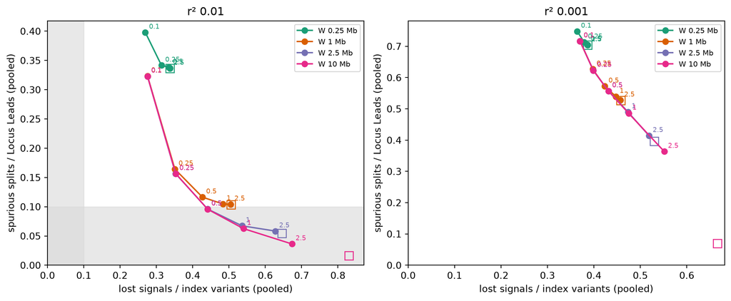

### Spurious splits by the lead’s |z|

D = 0.1 cM, W = 2.5 Mb, and the 2.5 Mb window.

| lead’s \|z\| | Locus Leads | spurious | rate | window: Locus Leads | window: spurious | window: rate |
| --- | --- | --- | --- | --- | --- | --- |
| [0,7) | 12,402 | 4,338 | 35.0% | 3,111 | 268 | 8.6% |
| [7,10) | 6,707 | 2,006 | 29.9% | 2,690 | 127 | 4.7% |
| [10,20) | 3,252 | 915 | 28.1% | 1,819 | 40 | 2.2% |
| [20,inf) | 648 | 169 | 26.1% | 437 | 5 | 1.1% |

### Chance LD at n = 771

Index variants on different chromosomes are unlinked, so the share of such pairs whose r² reaches a threshold is what chance gives at n = 771. These are within-Analysis pairs: two of one Analysis’s own index variants, never two variants drawn from the panel at large. Over 37 Analyses (at most 3,000 index variants each, chosen by a fixed seed) there are 13,823,613 such pairs, 9,139 with an undefined r² because a variant is constant in the panel. The share is of the 13,814,474 pairs with a defined r².

| r² at least | pairs | share of defined pairs |
| --- | --- | --- |
| 0.001 | 5,847,017 | 42.33% |
| 0.01 | 171,188 | 1.24% |
| 0.05 | 457 | 0.00% |
| 0.1 | 44 | 0.00% |

The panel’s own chance LD comes from the panel’s variants at large, not from one Analysis’s index variants among themselves. At r² 0.01 it is 1.16% for EUR, over 200,000 drawn pairs (`ancestries_chance_ld.json`, #405), against the 1.24% above. The two measure different pools, so they need not match.

A spurious split’s pair has r² at or above the clumping threshold by construction. What matters is how many of the long ones sit near the threshold, as chance pairs do. The verdict’s configuration at r² 0.01, pooled over the Analyses, by the pair’s distance:

| kind | distance | pairs | r² undefined | r² ≥ 0.001 | r² ≥ 0.01 | r² ≥ 0.05 | r² ≥ 0.1 |
| --- | --- | --- | --- | --- | --- | --- | --- |
| spurious splits | <=1Mb | 5,503 | 0 | 5,503 | 5,503 | 2,350 | 1,394 |
| spurious splits | 1-2.5Mb | 875 | 0 | 875 | 875 | 208 | 109 |
| spurious splits | 2.5-10Mb | 1,050 | 0 | 1,050 | 1,050 | 52 | 31 |
| spurious splits | >10Mb | 0 | 0 | 0 | 0 | 0 | 0 |
| lost signals | <=1Mb | 5,927 | 6 | 5,213 | 2,395 | 1,845 | 1,592 |
| lost signals | 1-2.5Mb | 2 | 0 | 2 | 1 | 1 | 1 |
| lost signals | 2.5-10Mb | 0 | 0 | 0 | 0 | 0 | 0 |
| lost signals | >10Mb | 0 | 0 | 0 | 0 | 0 | 0 |

Spurious splits by their pair’s r²: [0,0.001): 0, [0.001,0.01): 0, [0.01,0.02): 2,887, [0.02,0.05): 1,931, [0.05,0.1): 1,076, [0.1,0.5): 1,293, [0.5,inf): 241.

### The map’s two spikes

The mean map carries two single-population jumps found in #402. Each spike’s size is measured in `eur_sweep.json` from its population’s map: the jump from its map point to the next, and what the mean map keeps across the same interval.

| population | position | interval | population map | mean map keeps |
| --- | --- | --- | --- | --- |
| TSI | chr7:131,782,269 | 444 bp | 92.7 cM | 18.60 cM |
| GBR | chr1:235,056,161 | 23,295 bp | 33.6 cM | 6.76 cM |

Disagreements whose pair spans either:

| D | W | kind | pairs | spanning either | spanning TSI chr7:131,782,269 | spanning GBR chr1:235,056,161 |
| --- | --- | --- | --- | --- | --- | --- |
| 0.1 cM | 2.5 Mb | spurious splits | 7,428 | 4 | 3 | 1 |
| 0.1 cM | 2.5 Mb | lost signals | 5,929 | 0 | 0 | 0 |
| bp only | 2.5 Mb | spurious splits | 440 | 2 | 2 | 0 |
| bp only | 2.5 Mb | lost signals | 13,893 | 9 | 4 | 5 |

The comparison with a median map is #404’s, and it has been made:

`eur_maps` (#404) rebuilds the map as the median of the five populations’ rates and repeats this sweep on it. Across the two intervals above the median gains 0.084 cM on chr7 and 0.058 cM on chr1, where the mean gains 18.60 and 6.76: both spikes go; and it changes no verdict — C1 at 24 of 24, C2 at 20 of 24, C3 at no W on the median against C1 at 24 of 24, C2 at 20 of 24, C3 at no W on the mean (`eur_maps.json`).

## The disagreeing pairs

`eur_sweep_pairs.tsv.gz` holds every spurious split and lost signal at r² 0.01 for four configurations: 50,590 rows, sha256 `932dff97375156e0…`, checked against the JSON’s summaries here. Columns: `analysis`, `store`, `d_cm`, `w_bp`, `kind`, `alid`, `stronger_alid`, `abs_z`, `stronger_abs_z`, `r2`, `distance_bp`, `distance_cm`. `alid` is the Locus Lead (a spurious split) or the index variant (a lost signal); `stronger_alid` is the index variant whose clump holds the first, or the lead the second merged into. `r2` is `NA` where undefined.

| D | W | kind | pairs | r² undefined |
| --- | --- | --- | --- | --- |
| 0.1 cM | 2.5 Mb | spurious splits | 7,428 | 0 |
| 0.1 cM | 2.5 Mb | lost signals | 5,929 | 6 |
| 0.5 cM | 1 Mb | spurious splits | 1,623 | 0 |
| 0.5 cM | 1 Mb | lost signals | 9,182 | 6 |
| bp only | 1 Mb | spurious splits | 1,223 | 0 |
| bp only | 1 Mb | lost signals | 10,872 | 6 |
| bp only | 2.5 Mb | spurious splits | 440 | 0 |
| bp only | 2.5 Mb | lost signals | 13,893 | 6 |

## Reproduce

```bash
pixi run -e dev python -m prototypes.locus_leads select --stores /data/opengwasdb/stores \
    --seed 403 --output docs/benchmark-output/locus_leads/eur_sweep_selection.json
pixi run -e dev python -m prototypes.locus_leads sweep \
    --selection docs/benchmark-output/locus_leads/eur_sweep_selection.json \
    --stores-dir /data/opengwasdb/stores \
    --genetic-map /data/opengwasdb/reference/genetic-map/pyrho-1kg-hg38/EUR.tsv.gz \
    --panel /data/opengwasdb/reference/hgdp1kgp-hg38/pgen/EUR \
    --hm3 /data/opengwasdb/reference/hapmap3-hg38/hm3.grch38.alid.txt \
    --work-dir <scratch directory> --output docs/benchmark-output/locus_leads/eur_sweep.json
pixi run -e report quarto render docs/benchmark-output/locus_leads/eur_sweep.qmd
```